# Rossmann Store Sale

### 填充na值，并合并到train

```
##      Store          DayOfWeek          Date                Sales
##  Min.   :   1.0   Min.   :1.000   Min.   :2013-01-01   Min.   :    0
##  1st Qu.: 280.0   1st Qu.:2.000   1st Qu.:2013-08-17   1st Qu.: 3727
##  Median : 558.0   Median :4.000   Median :2014-04-02   Median : 5744
##  Mean   : 558.4   Mean   :3.998   Mean   :2014-04-11   Mean   : 5774
##  3rd Qu.: 838.0   3rd Qu.:6.000   3rd Qu.:2014-12-12   3rd Qu.: 7856
##  Max.   :1115.0   Max.   :7.000   Max.   :2015-07-31   Max.   :41551
##    Customers      Open       Promo      StateHoliday SchoolHoliday
##  Min.   :   0.0   0:172817   0:629129   0:986159     0:835488
##  1st Qu.: 405.0   1:844392   1:388080   a: 20260     1:181721
##  Median : 609.0                         b:  6690
##  Mean   : 633.1                         c:  4100
##  3rd Qu.: 837.0
##  Max.   :7388.0
##  HaveMissDate StoreType  Assortment CompetitionOpen
##  0:880769     a:551627   a:537445   Min.   :1990-06-01
##  1:136440     b: 15830   b:  8294   1st Qu.:2008-04-01
##               c:136840   c:471470   Median :2009-07-01
##               d:312912              Mean   :2009-06-04
##                                     3rd Qu.:2011-11-01
##                                     Max.   :2015-08-01
##  CompetitionDistance
##  Min.   :   20
##  1st Qu.:  710
##  Median : 2325
##  Mean   : 5422
##  3rd Qu.: 6880
##  Max.   :75860
```

接下来我们可以对比观察CompetitionOpen和销售额是否有关联。

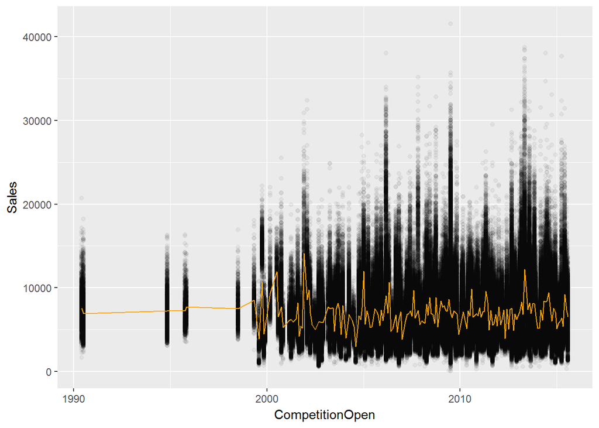

我们发现这样的图只能大概看出有一定的关系。为了捕捉到究竟竞争对手的出现对门店销量产生的影响，我们考虑增加一个变量来反应时间的变化。 我们增加了一个变量openlastmonth，即从某个时间点算起，竞争者经营时长，单位是月。 这里我希望观察到一个门店出现竞争者前及之后一年内的销售情况。

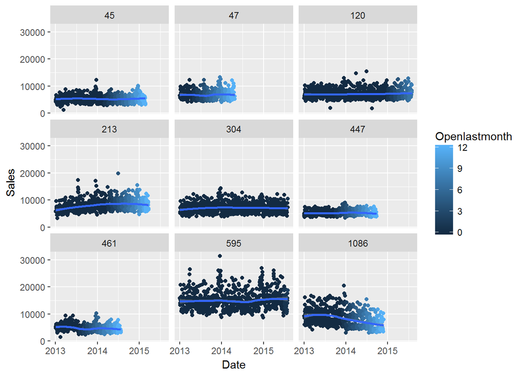

我们通过对比观察了一部分门店的情况，大致可以看出来对于竞争者的出现，对于有些门店销售额的波动并不大。而有些门店在竞争者出现后的一段时间内业绩出现明险下滑。考虑到竞争者不同，可能带来的影响也不同。经过观察有一些门店在下滑后会出现上扬趋势，这可能跟之后一些促销有关系。

接下来，我们查看下距离变量对sale有没有影响。

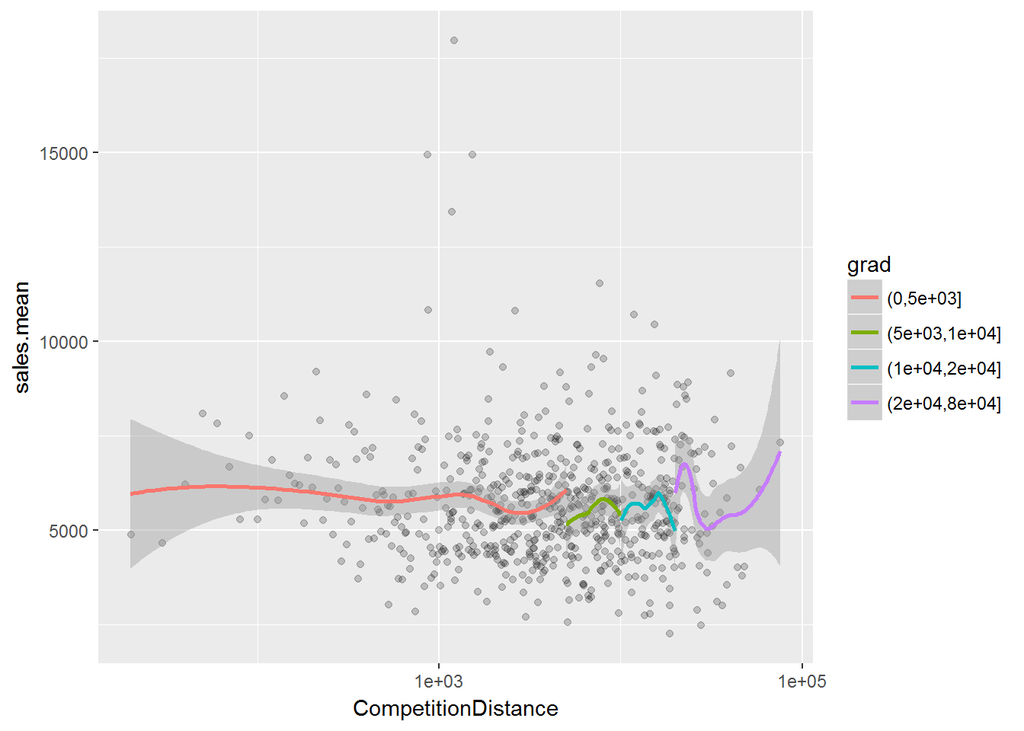

比较反直觉的是竞争者的距离和销售似乎有太大相关性。我们可以通过cor.test函数来进一步了解。

```
##
##  Pearson's product-moment correlation
##
## data:  sales.mean and CompetitionDistance
## t = -0.20831, df = 653, p-value = 0.8351
## alternative hypothesis: true correlation is not equal to 0
## 95 percent confidence interval:
##  -0.08470634  0.06849898
## sample estimates:
##          cor
## -0.008151518
```

这里看起来并没有相关性。

### 先将Promo2合并入train，以便做进一步观察。

接下来我们看下这个促销跟销售额有没有相关性

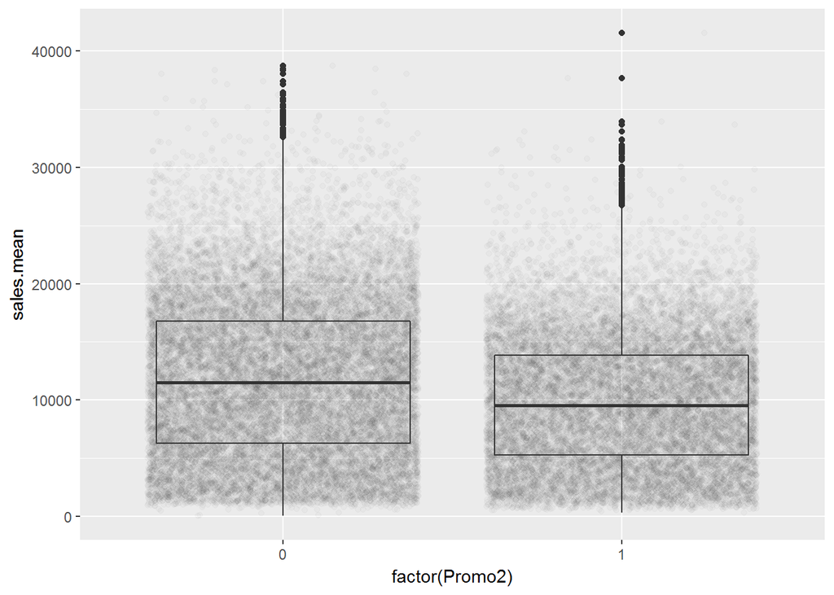

这里反直觉的是，没有参与这类促销的门店销售均值反而更高一些。可能正是由于销售不好，这些门店才选择促销来增加销售额吧。

参加一种促销的门店是否会参加另一种？

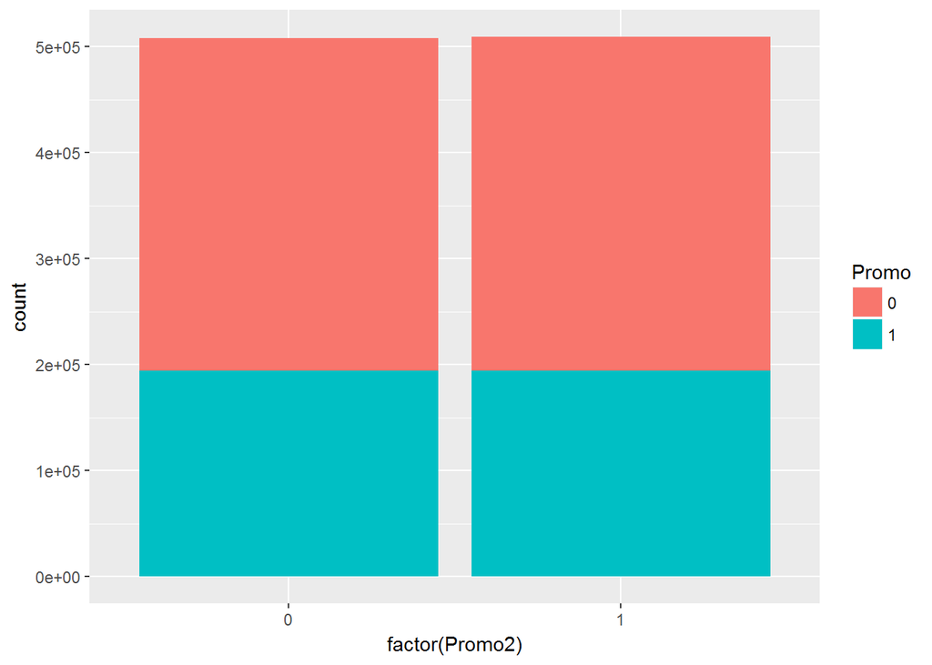

这两个变量没什么相关性。

# 测试集粗略分析

```
##        Id            Store          DayOfWeek             Date
##  Min.   :    1   Min.   :   1.0   Min.   :1.000   2015-08-01:  856
##  1st Qu.:10273   1st Qu.: 279.8   1st Qu.:2.000   2015-08-02:  856
##  Median :20545   Median : 553.5   Median :4.000   2015-08-03:  856
##  Mean   :20545   Mean   : 555.9   Mean   :3.979   2015-08-04:  856
##  3rd Qu.:30816   3rd Qu.: 832.2   3rd Qu.:6.000   2015-08-05:  856
##  Max.   :41088   Max.   :1115.0   Max.   :7.000   2015-08-06:  856
##                                                   (Other)   :35952
##       Open            Promo        StateHoliday SchoolHoliday
##  Min.   :0.0000   Min.   :0.0000   0:40908      Min.   :0.0000
##  1st Qu.:1.0000   1st Qu.:0.0000   a:  180      1st Qu.:0.0000
##  Median :1.0000   Median :0.0000                Median :0.0000
##  Mean   :0.8543   Mean   :0.3958                Mean   :0.4435
##  3rd Qu.:1.0000   3rd Qu.:1.0000                3rd Qu.:1.0000
##  Max.   :1.0000   Max.   :1.0000                Max.   :1.0000
##  NA's   :11
```

```
## 'data.frame':    41088 obs. of  8 variables:
##  $ Id           : int  1 2 3 4 5 6 7 8 9 10 ...
##  $ Store        : int  1 3 7 8 9 10 11 12 13 14 ...
##  $ DayOfWeek    : int  4 4 4 4 4 4 4 4 4 4 ...
##  $ Date         : Factor w/ 48 levels "2015-08-01","2015-08-02",..: 48 48 48 48 48 48 48 48 48 48 ...
##  $ Open         : int  1 1 1 1 1 1 1 1 1 1 ...
##  $ Promo        : int  1 1 1 1 1 1 1 1 1 1 ...
##  $ StateHoliday : Factor w/ 2 levels "0","a": 1 1 1 1 1 1 1 1 1 1 ...
##  $ SchoolHoliday: int  0 0 0 0 0 0 0 0 0 0 ...
```

测试集有8个变量41088条观察。Open变量有11个NA值。StateHoliday变量不同于训练集的4种值，在测试集里只有0和a两种。

### 对测试集操作：变量类型转换

```
##         Min.      1st Qu.       Median         Mean      3rd Qu.
## "2015-08-01" "2015-08-12" "2015-08-24" "2015-08-24" "2015-09-05"
##         Max.
## "2015-09-17"
```

我们的预测目标是15年8月到9月17号这段时间。 查看下训练集中89月份的stateholiday

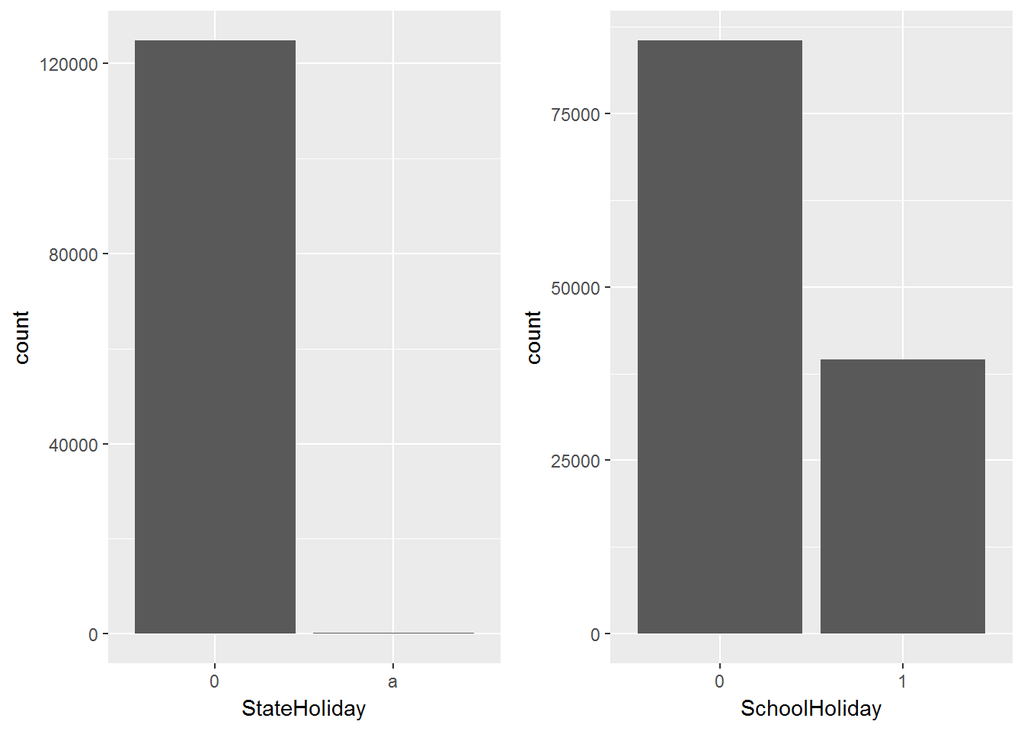

可以看出来这两个月份确实只有0，a两种值，schoolholiday变量这两个月份1的比率比整体要高。应该跟暑期有关。

[output not shown]

622分店9-5到17期间Open值缺失，这里判断应该填充为1。这里即没有StateHoliday也没有SchoolHoliday. 也不是周日。

### 对测试集操作：填充缺失值

# 最后总结

## 图一

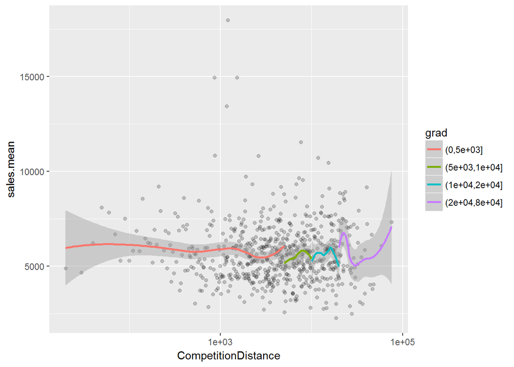

在画图前，我直觉的以为竞争对手的距离会是影响销售的重要因素，而就目前来看两者并没有相关性。之后会尝试结合其它变量做进一步分析。

## 图二（代码参考kaggle)

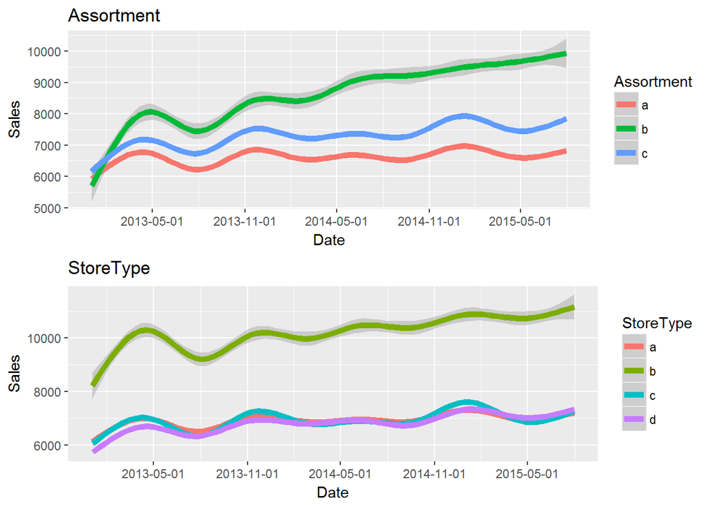

这里可以看出Assortment变量中a,c的趋势比较接近，而销售平均水平不同。而b分类整体呈上升趋势，平均销售水平远高于其它类型。同样商店类型b的平均销售水平和趋势明显不同于其它分类。

## 图三

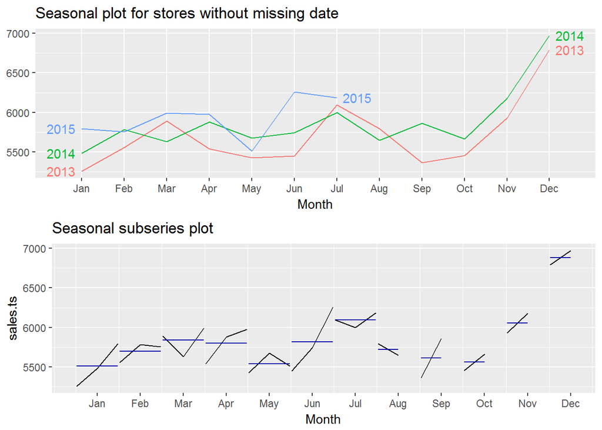

总体来讲，这个数据集以及预测的目标都是时间序列的。那么可能会有一些季节性的规律存在。这里我们按月份画出不同年份月平均销售额的走势。这里去掉了缺失半年销售数据的门店，虽然丢掉了不少样本，但考虑到这里的目的是捕捉季节性规律，因此作为权衡，我们在这里只使用日期完整的门店数据。大致上可以看出有一些走势相同的月份，比如1月可能受12月份消费高峰期影响会比较低，而到了2，3月份有所回升。这可能跟2月份的假期有关系。到了5月份明显的下滑，过后双出现了销售峰期。我们在subseries里能看到每个月份，三年的走势。我们看到有些月份趋势是逐年上升，而有些月份发生了方向变化。

## 反思

因为数据样本比较多，当我们想通过日期来观察趋势的时候遇到了一些问题。因为每个日期都有1000多个观察样本，而训练集就包含了两年多的观察数据。因此会出现很多干扰，不能清晰的观察到一些潜在的特征影响。当换一种方式来绘制的时候这些规律才显现出来。这里还有三个变量没有加入训练集，这将是之后的工作。 考虑到这个变量也是预测目标在前面过早的丢掉了customer变量。在最后做季节性绘图的时候，突然想到这个变量可能可以帮助我们观察到一些规律。对于有些门店来说，比如社区附近，可能销售有很大一部分来自于相对固定的消费群。那么他们可能会不会有一些比较固定的消费习惯呢？当然这个只是猜测，需要之后做一些分析。 除此之外，这个数据集还有一些工作待尝试。比如，我们要预测的是一个时间点之后的销售，那么我们能不能通过观察时间点之前的一段时间的情况得出一些有用的信息？此外，还有一个滞后性的因素可能需要考虑。比如当出现竞争对手或者当采取了持续性促销后，对销售额的影响可能会有一些滞后性。 之后会尝试多变量观察，尝试的重点，我想可能还会放在时间趋势上。